# Loan Data from Prosper

**By Abdelrhman Ragab Nady**

### What is the structure of your dataset?

> The dataset has 113,937 loans with 81 variables on each loan. I will be interested in a subset of those variables including loan amount, borrower rate, Borrower APR, current loan status, borrower income, and many others. Variables are loan information and borrower information.

### What is/are the main feature(s) of interest in your dataset?

> I'm most interested in figuring out what features are best for predicting borrower's Annual Percentage Rate (Borrower APR) for the loan and affecting the loan status.

### What features in the dataset do you think will help support your investigation into your feature(s) of interest?

> I guess that the total loan amount will have a great effect on the APR of the loan which the most larger the total loan amount, the most the lower the APR. I also guess that the borrowers stated monthly income, loan term, Prosper rating, employment status will also have effects on the APR.

> I also guess I need to invest and find in ListingCreationDate and some borrower information such as Occupation, AvailableBankcardCredit, CreditGrade, StatedMonthlyIncome, and DebtToIncomeRatio which will also have effects on the borrower's Annual Percentage Rate and loan status.

**How Many Missing in the Data Set?**

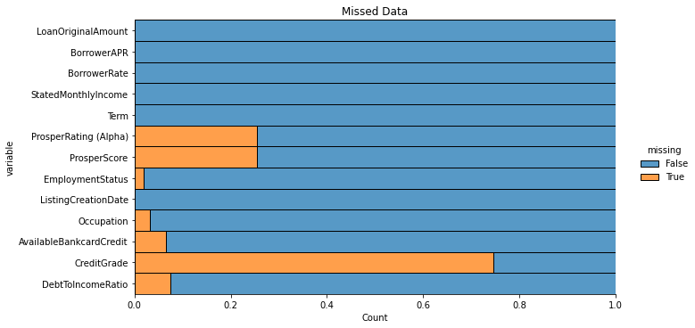

```python
sns.displot(
    data=selected_data.isna().melt(value_name="missing"),
    y="variable",
    hue="missing",
    multiple="fill",
    aspect=2
);
plt.title('Missed Data');
```

> we have a greatly missed data in **Credit Grade** so maybe result of analysis of this feature isn't accurate, **ProsperRating (Alpha)**, **ProsperScore EmploymentStatus**, **DebtToIncomeRatio**, **Occupation**, and **AvailableBankcardCredit** all of these columns contain nulls value

> **ProsperRating (Alpha)**: The Prosper Rating assigned at the time the listing was created between AA - HR. Applicable for loans originated after July 2009.

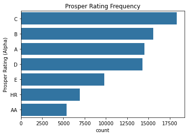

```python
# Plot the Prosper Rating
type_order = selected_data['ProsperRating (Alpha)'].value_counts().index
sns.countplot(data=selected_data, y='ProsperRating (Alpha)', color=base_color, order=type_order);
plt.ylabel('Prosper Rating (Alpha)');
plt.title('Prosper Rating Frequency');
```

Next up, the first predictor variable of interest: BorrowerAPR and BorrowerRate

> **BorrowerAPR** : The Borrower's Annual Percentage Rate (APR) for the loan.  
> **BorrowerRate** : The Borrower's interest rate for this loan.

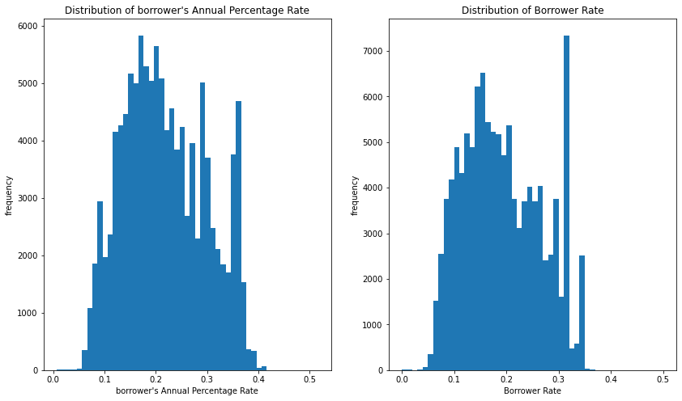

```python
plt.subplots(figsize = [14,8])
plt.subplot(1, 2, 1)
apr_bins = np.arange(selected_data.BorrowerAPR.min(), selected_data.BorrowerAPR.max()+0.01, 0.01)
plt.hist(data=selected_data, x='BorrowerAPR', bins=apr_bins);
plt.xlabel('borrower\'s Annual Percentage Rate');
plt.title('Distribution of borrower\'s Annual Percentage Rate');

plt.ylabel('frequency');
# Plot the distribution of BorrowerRate
plt.subplot(1, 2, 2)
rate_bins = np.arange(selected_data['BorrowerRate'].min(), selected_data.BorrowerRate.max()+0.01, 0.01)
plt.hist(data=selected_data, x='BorrowerRate', bins=rate_bins)
plt.xlabel('Borrower Rate');
plt.ylabel('frequency');
plt.title('Distribution of Borrower Rate');
```

> Both distributions are multimodal which the distributions are a normal distribution than skewed right. Borrower Rate and borrower's Annual Percentage Rate are similar but we considered that borrower's Annual Percentage Rate contain some fees (such as discount points, most closing costs, mortgage insurance, and loan origination fees) of course them affect on the total cost of loan.  
> **So that borrower's Annual Percentage Rate greater than Borrower Rate**

> Next up, the first predictor variable of interest: Occupation  
> **Occupation**: The Occupation selected by the Borrower at the time they created the listing.

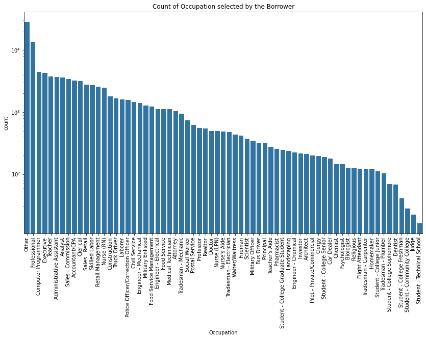

```python
plt.subplots(figsize = [14,8])
type_order = selected_data['Occupation'].value_counts().index
g = sns.countplot(data=selected_data, x='Occupation', color=base_color, order=type_order);
plt.xticks(rotation=90)
plt.title('Count of Occupation selected by the Borrower');
g.set(yscale="log");
```

> Because I noted huge variance between highest and lowest counts. I used **Log Scale** in my chart  
> I found The most common Occupation is **‘Others’** then **‘Professional’**, and not give us meaningful information so we will skip them and move to next ones we found that **‘computer programmer’**,**’Excutives’**, **‘Teacher’**, **'Administrative Assistant'**, and **'Analyst'**.

| Occupation | frequency |
| --- | --- |
| Computer Programmer | 4478 |
| Executive | 4311 |
| Teacher | 3759 |
| Administrative Assistant | 3688 |
| Analyst | 3602 |
| Sales - Commission | 3446 |
| Accountant/CPA | 3233 |
| Clerical | 3164 |

> Next up, the first predictor variable of interest: **DebtToIncomeRatio**  
> **DebtToIncomeRatio**: The debt to income ratio of the borrower at the time the credit profile was pulled. This value is Null if the debt to income ratio is not available. This value is capped at 10.01 (any debt to income ratio larger than 1000% will be returned as 1001%).

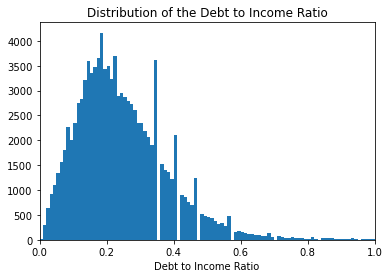

```python
in_bins = np.arange(selected_data.DebtToIncomeRatio.min(), selected_data.DebtToIncomeRatio.max()+0.01, 0.01)
plt.hist(data=selected_data, x='DebtToIncomeRatio', bins=in_bins);
plt.xlim(0,1);
plt.xlabel('Debt to Income Ratio');
plt.title('Distribution of the Debt to Income Ratio');
```

**What's relationship between Term and the CreditGrade/ProsperRating(s) and ProsperScore ?**

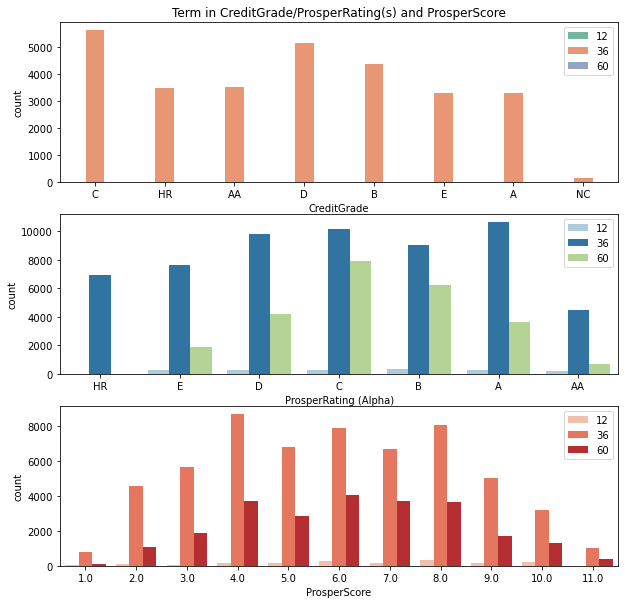

```python
# Look at relationship between Term and the CreditGrade/ProsperRating(s) and ProsperScore
plt.figure(figsize=[10,10])



plt.subplot(3,1,1)
sns.countplot(data=selected_data, x='CreditGrade', hue='Term', palette='Set2');
plt.legend(loc=1);
plt.title("Term in CreditGrade/ProsperRating(s) and ProsperScore");

plt.subplot(3,1,2)
sns.countplot(data=selected_data, x='ProsperRating (Alpha)', hue='Term', palette='Paired');
plt.legend(loc=1);


plt.subplot(3,1,3)
sns.countplot(data=selected_data, x='ProsperScore', hue='Term', palette='Reds');
plt.legend(loc=1);
```

**What's relation between Loan Original Amount and Borrower APR?**

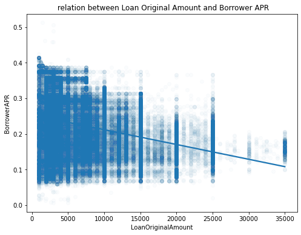

```python
plt.figure(figsize = [8, 6])
sns.regplot(data = selected_data, x = 'LoanOriginalAmount', y = 'BorrowerAPR', scatter_kws={'alpha':1/50});
plt.title(" relation between Loan Original Amount and Borrower APR");
```

> This graph observed that at the different sizes of the total loan amount, the borrower's APR has a large distribution, but the range of APR decreases with the increase of loan amount. So the borrower's APR is negatively correlated with the total loan amount.

**What's most common Employment Status in each Prosper Rating ?**

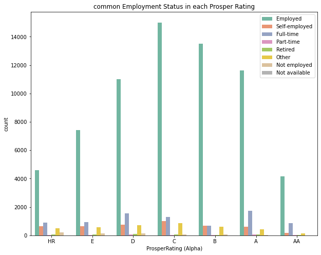

```python
plt.figure(figsize = [10, 8])
sns.countplot(data=selected_data, x='ProsperRating (Alpha)', hue='EmploymentStatus', palette='Set2');
plt.legend(loc=1);
plt.title("common Employment Status in each Prosper Rating");
```

> Lower ratings were noted to have greater proportions of individuals with employment status Not Employed, Self-employed, Retired, and Part-Time.

**What's correlation between (CreditGrade, the ProsperRating, and ProsperScore) to BorrowerRate ?**

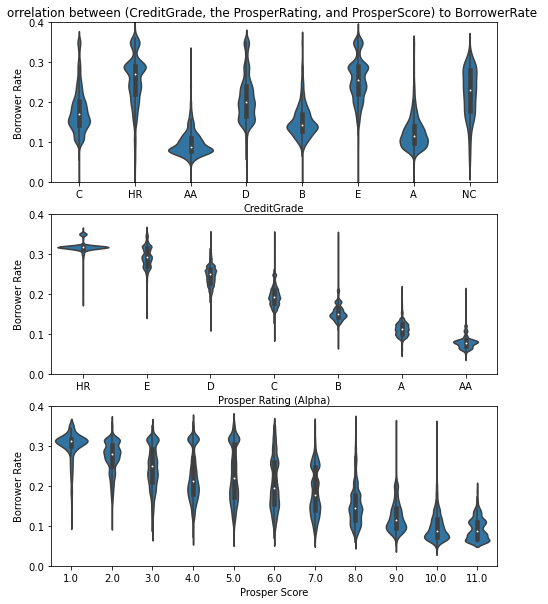

```python
plt.figure(figsize=[8,10])
plt.subplot(3,1,1)
sns.violinplot(data=selected_data, x='CreditGrade', y='BorrowerRate', color=base_color);
plt.ylim((0,0.4));
plt.xlabel("CreditGrade");
plt.ylabel("Borrower Rate");
plt.title("orrelation between (CreditGrade, the ProsperRating, and ProsperScore) to BorrowerRate ");


plt.subplot(3,1,2)
sns.violinplot(data=selected_data, x='ProsperRating (Alpha)', y='BorrowerRate', color=base_color);
plt.ylim((0,0.4));
plt.xlabel("Prosper Rating (Alpha)");
plt.ylabel("Borrower Rate");

plt.subplot(3,1,3)
sns.violinplot(data=selected_data, x='ProsperScore', y='BorrowerRate', color=base_color);
plt.ylim((0,0.4));
plt.xlabel("Prosper Score");
plt.ylabel("Borrower Rate");
```

> Violin plots show the distribution of the different credit risks and the BorrowerRate is that there is a negative correlation between having a higher score and a lower interest rate. This is once again most pronounced in the results for the ProsperRating (Alpha) variable where the decline is steeper. With ProsperScore there is still a decline, but the distribution of the BorrowerRate is more distributed and the IQR is generally larger for each rating.

**How The rating and term affect on Borrower APR ?**

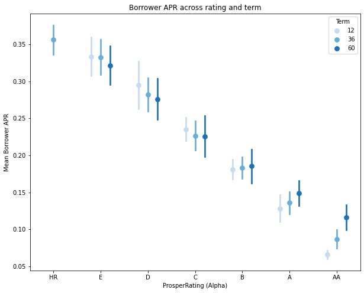

```python
plt.figure(figsize = [10,8])
sns.pointplot(data = selected_data, x = 'ProsperRating (Alpha)', y = 'BorrowerAPR', hue = 'Term',
           palette = 'Blues', linestyles = '', dodge = 0.4, ci='sd')
plt.title('Borrower APR across rating and term')
plt.ylabel('Mean Borrower APR');
```

> Finally, let's look at relationships between the three categorical features.  
> **how the BorrowerRate changes for different loan Terms when split up by ProsperRating?**

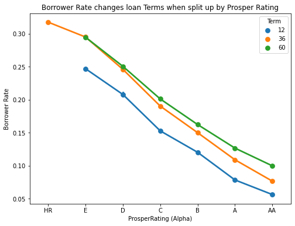

```python
# Create a pointplot to show how the BorrowerRate changes for different loan Terms
# when split up by ProsperRating
plt.figure(figsize=[8,6])

sns.pointplot(data=selected_data, x='ProsperRating (Alpha)', y='BorrowerRate', hue='Term',
                   palette='tab10');
plt.legend(loc=1, title='Term');
plt.title('Borrower Rate changes loan Terms when split up by Prosper Rating');
plt.ylabel(' Borrower Rate ');
```

> This seems to not make sense but for every single level of the ProsperRating, the BorrowerRate increases as for longer-term loans. I would think it to be the reverse as shorter-term loans usually carry a higher interest rate. This was not at all evident in the bivariate analysis and comes a bit as a surprise.